# TP – Modèles de durée sous R (Poly)

Master 2 – Économétrie appliquée

Etienne Dagorn

01 December 2025

# 1 Introduction

Ce TP introduit les **modèles de durée** sous R via les outils classiques du package `{survival}`.

Nous utilisons les données `pbc`, issues d’un essai clinique sur la cirrhose biliaire primitive.

À la fin du TP, vous devrez être capables de :

- construire correctement un objet `Surv()` (durée + censure) ;
- tracer et interpréter des courbes de survie non paramétriques (Kaplan–Meier) ;
- utiliser l’estimateur de Nelson–Aalen pour diagnostiquer la forme du hazard ;
- estimer et interpréter des modèles paramétriques (exponentiel, Weibull) ;
- estimer un modèle de Cox (PH) et un modèle AFT, et comparer leurs interprétations ;

**Plan de la séance (3h)**

1. Comprendre et coder les données de durée (`Surv()`).
2. Estimer et tracer une courbe Kaplan–Meier (et KM “à la main”).
3. Introduire Nelson–Aalen et le test du log-rank.
4. (Si temps) Modèles paramétriques et modèles avec covariables (Cox / AFT).

# 2 Rappels Markdown

**Bonnes pratiques RMarkdown**

- Un chunk `setup` avec `include = FALSE` pour charger les packages.
- Un `set.seed()` unique au début pour rendre vos résultats reproductibles.
- Commenter vos gros blocs de code pour expliquer ce que vous faites (pas seulement “Exercice 1”).

# 3 Les principaux packages utilisés en analyse de survie sous R

Cette section présente les packages essentiels que vous utiliserez tout au long du TP.  
Ils permettent d’estimer, visualiser et interpréter les modèles de durée.

## 3.1 `{survival}` — Le package indispensable

Le package **de base** pour toute analyse de survie en R.  
Il fournit les briques fondamentales pour :

- représenter les données de durée et de censure ;
- estimer des courbes de survie non paramétriques (Kaplan–Meier, Nelson–Aalen) ;
- ajuster des modèles paramétriques et semi-paramétriques (exponentiel, Weibull, Cox).

Dans un TP, c’est souvent **le seul package vraiment indispensable** : les autres (`survminer`, `ggsurvfit`…) servent surtout à améliorer les graphiques ou la présentation.

### 3.1.1 Les fonctions clés de `{survival}`

#### 3.1.1.1 `Surv()` — Construire l’objet de survie

La fonction **fondamentale** : elle encode pour chaque individu le couple $(t_i, \delta_i)$.

```r
S <- Surv(time = df$time, event = df$status == 2)
```

Principales variantes :

- **Censure à droite (cas le plus courant)**

  ```r
  Surv(time, event)
  ```

- **Données start–stop (processus en comptage)**

  ```r
  Surv(time_start, time_stop, event)
  ```

- **Censure par intervalle**

  ```r
  Surv(time_left, time_right, type = "interval2")
  ```

> Dans l’affichage de `Surv`, un `+` indique une **observation censurée**.

#### 3.1.1.2 `survfit()` — Kaplan–Meier et hazard cumulé

Permet d’estimer :

- la **courbe de survie** Kaplan–Meier ;
- le **hazard cumulé** (Nelson–Aalen / Fleming–Harrington) ;
- des survies **par groupe**.

```r
# Survie globale
km <- survfit(S ~ 1)

# Survie par groupe (ex. sexe)
km_sex <- survfit(S ~ sex, data = df)
```

Pour le **hazard cumulé** (Nelson–Aalen) :

```r
na <- survfit(S ~ 1, type = "fh")  # Fleming–Harrington ~ Nelson–Aalen
```

Les objets retournés contiennent : - `time` : temps distincts où un événement a lieu ; - `n.risk` : nombre à risque ; - `n.event` : nombre d’événements ; - `surv` : survie estimée $\hat S(t)$ ; - `std.err`, `lower`, `upper` : erreurs standard et bornes d’IC.

#### 3.1.1.3 `coxph()` — Modèle de Cox à risques proportionnels (PH)

Ajuste le modèle semi-paramétrique le plus utilisé en analyse de survie.

```r
cox1 <- coxph(S ~ age + sex + bili, data = df)
summary(cox1)
```

On obtient notamment :

- les coefficients $\hat \eta$ ;
- les **hazard ratios** via `exp(coef(cox1))` ;
- des tests (Wald, score, vraisemblance) ;
- la log-vraisemblance du modèle.

#### 3.1.1.4 `cox.zph()` — Vérifier l’hypothèse de risques proportionnels

Teste si l’effet des covariables est **constant dans le temps** (hypothèse PH).

```r
zph <- cox.zph(cox1)
zph
```

Couplé avec :

```r
ggcoxzph(zph)  # via le package {survminer}
```

pour un diagnostic graphique.

### 3.1.2 `survreg()` — Modèles paramétriques et AFT

Permet d’ajuster des modèles **paramétriques** ou de type **Accelerated Failure Time (AFT)**.

```r
aft_weib <- survreg(S ~ age + sex + bili,
                    data = df, dist = "weibull")
summary(aft_weib)
```

Distributions usuelles :

- `"exponential"`
- `"weibull"`
- `"lognormal"`
- `"loglogistic"`

Les coefficients de `survreg()` s’interprètent sur l’échelle de $\log(T)$, et leur exponentielle donne des **time ratios**.

### 3.1.3 `survdiff()` — Test du log-rank

Compare des courbes de survie entre groupes.

```r
test_lr <- survdiff(S ~ sex, data = df)
test_lr
```

La sortie fournit une statistique de type $\chi^2$. Le p-value associé se calcule par :

```r
chi2 <- as.numeric(test_lr$chisq)
pval <- 1 - pchisq(chi2, df = 1)  # si deux groupes
```

## 3.2 Résumé des fonctions à connaître

| Fonction | Rôle principal |
| --- | --- |
| `Surv()` | Créer l’objet de survie (durée + censure) |
| `survfit()` | Estimer KM et hazard cumulé (NA/FH) |
| `coxph()` | Ajuster un modèle de Cox (PH) |
| `cox.zph()` | Tester la proportionnalité des risques (PH) |
| `survreg()` | Modèles paramétriques / AFT (exp, Weibull) |
| `survdiff()` | Test du log-rank entre groupes |

## 3.3 `{survminer}` — Courbes de survie claires et lisibles

Ce package est spécialisé dans la **visualisation** des objets issus de `{survival}`.

### 3.3.1 Ce qu’il permet de faire

- Tracer facilement les courbes Kaplan–Meier.
- Ajouter des tables de risque automatiquement.
- Afficher les intervalles de confiance.
- Visualiser les diagnostics PH du modèle de Cox.

### 3.3.2 Fonctions à connaître

- `ggsurvplot()` : graphique Kaplan–Meier prêt à l’emploi ;
- `ggcoxzph()` : graphique du test PH (résidus de Schoenfeld).

## 3.4 `{ggsurvfit}` — Alternative moderne pour les courbes de survie

Package léger, pensé pour les étudiants.  
Il produit des courbes propres, lisibles et intuitives.

### 3.4.1 Ce qu’il permet de faire

- Tracer une courbe Kaplan–Meier simple.
- Ajouter des intervalles de confiance.
- Ajouter des indicateurs de censure.
- Ajouter des tables d’effectifs.

## 3.5 `{cmprsk}` — Étudier les risques concurrents

Quand plusieurs événements possibles se font concurrence  
(ex : *décès* vs *greffe* dans les données PBC),  
ce package devient intéressant.

### 3.5.1 Ce qu’il permet de faire

- Estimer la **probabilité cumulée** d’un événement par cause (`cuminc()`).
- Ajuster un **modèle de Fine–Gray** (`crr()`).

## 3.6 `{gtsummary}` — Produire des tableaux de résultats

Très utilisé en biostatistique, ce package permet de transformer les sorties de modèle en **tableaux propres et lisibles**, au format publication.

### 3.6.1 Ce qu’il permet de faire

- Présenter proprement un modèle de Cox.
- Ajouter les hazard ratios, intervalles de confiance et p-values.
- Formater automatiquement le tableau.

## 3.7 Résumé des packages

| Package | À quoi sert-il ? |
| --- | --- |
| `survival` | Modèles de survie (KM, Cox, paramétriques). |
| `survminer` | Graphiques KM riches et lisibles. |
| `ggsurvfit` | Courbes KM simples, pédagogiques. |
| `cmprsk` | Risques concurrents (Fine–Gray). |
| `gtsummary` | Tableaux professionnels pour modèles de survie. |

**Mémo en 10 lignes**

- Objet de survie : `S <- Surv(time, event)`
- Courbe KM globale : `survfit(S ~ 1)`
- KM par groupe : `survfit(S ~ groupe)`
- Graphique : `ggsurvplot()`
- Hazard cumulé : `survfit(S ~ 1, type = “fh”)` + `ggsurvplot(…, fun = “cumhaz”)`
- Modèle de Cox : `coxph(S ~ X1 + X2, data = df)`
- PH ? `cox.zph()` (+ `ggcoxzph()`)
- Modèle AFT Weibull : `survreg(S ~ X1 + X2, dist = “weibull”)`
- HR = `exp(coef(cox))`
- TR = `exp(coef(aft))`

# 4 Mise en place

```r
library(survival)
library(survminer)
library(dplyr)
library(ggplot2)

data(pbc)
df <- pbc
```

# 5 Ex1 – Exploration des données, codage et censure

> **Objectif de cours :** comprendre le couple $(t_i, \delta_i)$, le rôle de la censure, et comment cela se reflète dans le code `Surv()`.

## 5.1 Aperçu général des données

```r
head(df)
str(df)
summary(df$time)
table(df$status)
```

En analyse de survie, chaque individu est résumé par le couple $(t_i,\delta_i)$, où :

- $t_i$ = durée d’observation,
- $\delta_i = 1$ si l’événement est observé, $\delta_i = 0$ si l’observation est censurée.

La vraisemblance s’écrit alors :

$$L(\theta)
= \prod_{\delta_i = 1} f(t_i \mid \theta)
\times
\prod_{\delta_i = 0} S(t_i \mid \theta).$$
Si `event` est mal codé → toute l’analyse est biaisée.

**Questions**

1. Quelle est la variable de durée dans les données PBC ?
2. Quelle variable indique l’événement (décès) ?
3. Calculez la proportion de censures :

   ```r
   mean(df$status == 0)
   ```

4. **Combien de modalités distinctes a la variable `status` ?**

   ```r
   table(df$status)
   ```

   → Interprétez chaque modalité : laquelle correspond à la censure ? Au décès ? À une greffe ?
5. **La variable `time` contient-elle des valeurs aberrantes ?**

   ```r
   summary(df$time)
   ```

   → Y a-t-il des durées très courtes (< 5 jours) ou très longues (> 4000 jours) ?  
   Comment cela pourrait-il affecter une estimation paramétrique ?
6. **La censure semble-t-elle administrative ou liée à un mécanisme plus complexe ?**

   ```r
   plot(df$time, df$status == 0)
   ```

   → Censures concentrées en fin de suivi → censure administrative.  
   → Sinon → possible censure informative.
7. **Quelles seraient les conséquences d’un codage incorrect de l’événement ?**
   - un décès codé comme censure ;
   - une censure codée comme décès.

   Expliquez l’impact sur la courbe KM et sur un modèle de Cox.
8. **Pourquoi `delta_i` doit-il être binaire (0/1 ou TRUE/FALSE) ?**

   Que se passerait-il si on conservait les valeurs brutes 0 / 1 / 2 dans `Surv()` ?
9. **Combien d’individus sont observés avant 1000 jours ?**

   ```r
   sum(df$time < 1000)
   ```

   → Expliquez pourquoi cela influence la précision de la KM au début du suivi.
10. **Quelle est la médiane brute des durées (sans censure) ?**

    ```r
    median(df$time)
    ```

    → Pourquoi cette médiane n’est-elle pas une médiane de survie ?
11. **Peut-on détecter rapidement si la censure dépend d’une covariable ?**

    ```r
    tapply(df$status == 0, df$sex, mean)
    ```

    → Si les différences sont fortes, que cela implique-t-il pour une analyse naïve ?

## 5.2 Objet `Surv()` et première courbe Kaplan–Meier

### 5.2.1 Création de l’objet `Surv()`

```r
S <- Surv(time = df$time,
          event = df$status == 2)  # 2 = décès
S
```

**Rôle de `Surv()`**
L’objet `Surv()` encode pour chaque individu le couple $(t_i, \delta_i)$ utilisé dans la vraisemblance :
$$L(\theta) = \prod_{\delta_i = 1} f(t_i \mid
\theta) \times \prod_{\delta_i = 0} S(t_i \mid \theta).$$

- $\delta_i = 1$ (événement observé) → contribution via la densité $f(t_i)$ ;
- $\delta_i = 0$ (censuré) → contribution via la survie $S(t_i)$.

Dans l’affichage de `Surv`, un `+` à droite d’un temps indique une observation **censurée**.

**Questions de compréhension**

1. En regardant `S[1:10]`, repérez :
   - un individu pour lequel l’événement est observé ;
   - un individu pour lequel l’observation est censurée (avec `+`).

   Pour chacun, notez $(t_i, \delta_i)$.
2. Pourquoi est-il important de coder `event` en 0/1 ou TRUE/FALSE plutôt qu’en 0/1/2 ? *Indice :* que se passerait-il si vous écriviez

   ```r
   S_bad <- Surv(time = df$time, event = df$status)
   ```

   en gardant les 3 modalités de `status` ? Que voyez-vous dans `S_bad[1:10]` ?
3. Dans les données PBC, nous avons choisi “décès” comme événement d’intérêt. Proposez un autre choix raisonnable d’événement (par exemple “décès ou greffe”) et écrivez le code pour l’objet `Surv` correspondant.
4. La définition de `S` dépend uniquement de deux vecteurs : `time` et `event`. Donnez deux exemples de situations (dans un autre contexte que PBC) où :
   - la variable de temps serait un temps d’attente ;
   - l’événement d’intérêt serait différent.

### 5.2.2 Première courbe KM avec `survfit()` et `ggsurvplot()`

```r
km <- survfit(S ~ 1)

ggsurvplot(
  km,
  conf.int   = TRUE,
  risk.table = TRUE,
  censor     = TRUE,
  ggtheme    = theme_minimal(),
  xlab       = "Temps (jours)",
  ylab       = "Probabilité de survie"
)
```

**Pourquoi l’estimateur KM fonctionne ?**
L’estimateur de Kaplan–Meier maximise une vraisemblance non paramétrique :
$$\hat S(t) = \prod_{t_i \le t} \left(1 -
\frac{d_i}{n_i}\right),$$
où $d_i$ est le nombre d’événements au temps $t_i$ et $n_i$ le nombre d’individus à risque juste avant $t_i$.

**Lecture rapide de la KM**

1. **Médiane de survie :**  
   À peu près à quel temps la survie passe-t-elle sous 0,5 (médiane de survie si elle existe) ? Si la courbe ne passe jamais sous 0,5, que peut-on dire de la médiane de survie ?
2. **Rôle des censures :**  
   Comment les censures (petits traits ou symboles) modifient-elles la forme de la courbe par rapport à une courbe sans censure ? Donnez un exemple de segment de la courbe où l’on observe des censures mais aucun événement.
3. **Table de risque :**  
   À partir de quel temps la table de risque indique-t-elle qu’il reste très peu d’individus à risque ? Que conclure sur la fiabilité de la forme de la courbe à droite (fin de suivi) ?
4. **Lecture ponctuelle de S(t) :**  
   Lisez graphiquement $\hat S(1000)$ et $\hat S(2000)$. Comment interpréter la différence entre ces deux valeurs en termes de probabilité de survie ?
5. **Lien avec la vraisemblance :**
   En vous appuyant sur la formule
   $$\hat S(t) = \prod_{t_i \le t}\left(1 -
   \frac{d_i}{n_i}\right),$$
   expliquez en une phrase ce que représente le facteur $1 - d_i / n_i$ au temps $t_i$. Pourquoi peut-on l’interpréter comme une probabilité conditionnelle de « survivre juste après $t_i$ » ?
6. **Effet de la troncature de l’axe des temps :**  
   Modifiez le graphique pour limiter l’axe des abscisses à 3000 jours (argument `xlim = c(0, 3000)` dans `ggsurvplot`). La conclusion sur la médiane de survie et la forme globale de la courbe change-t-elle ? Comment le choix de l’échelle de temps peut-il influencer la perception visuelle des résultats ?
7. **Sans intervalle de confiance :**  
   Reproduisez le graphique en mettant `conf.int = FALSE`. Est-ce plus « lisible » ? Quelles informations importantes perdez-vous en supprimant les intervalles de confiance ?

# 6 Ex2 – Construire une courbe de survie « à la main »

> **Objectif de cours :** reconstruire pas à pas l’estimateur de Kaplan–Meier,  
> comprendre le rôle des quantités $t_i, d_i, n_i$,  
> et visualiser comment elles déterminent toute la courbe de survie.

## 6.1 Sous-échantillon et définition de l’événement

On commence par extraire un sous-échantillon de taille modérée pour garder des tables lisibles.

|  | time | event | is_cens |
| --- | --- | --- | --- |
| 1 | 71 | 1 | FALSE |
| 2 | 140 | 1 | FALSE |
| 3 | 191 | 1 | FALSE |
| 4 | 207 | 1 | FALSE |
| 5 | 264 | 1 | FALSE |
| 6 | 264 | 1 | FALSE |

**Questions :**

1. Dans le codage ci-dessus, que représentent exactement les variables `event` et `is_cens` ?

## 6.2 Temps de décès et construction de la table (t_i, d_i, n_i)

On construit maintenant une table de survie où chaque ligne correspond à un temps où au moins un événement (décès) se produit.

| time | d_i | c_i |
| --- | --- | --- |
| 71 | 1 | 0 |
| 140 | 1 | 0 |
| 191 | 1 | 0 |
| 207 | 1 | 0 |
| 264 | 2 | 0 |
| 326 | 1 | 0 |

On ne garde que les temps où il y a au moins un décès, car ce sont les seuls temps où la survie va “descendre”.

| time | d_i | c_i | cumulative_events | cumulative_censor | n_i |
| --- | --- | --- | --- | --- | --- |
| 71 | 1 | 0 | 1 | 0 | 150 |
| 140 | 1 | 0 | 2 | 0 | 149 |
| 191 | 1 | 0 | 3 | 0 | 148 |
| 207 | 1 | 0 | 4 | 0 | 147 |
| 264 | 2 | 0 | 6 | 0 | 146 |
| 326 | 1 | 0 | 7 | 0 | 144 |
| 334 | 1 | 0 | 8 | 0 | 143 |
| 348 | 1 | 0 | 9 | 0 | 142 |
| 460 | 1 | 0 | 10 | 0 | 141 |
| 466 | 1 | 0 | 11 | 0 | 140 |

[output cut: 43 more lines]

**Questions :**

1. Vérifiez que `n_i` décroît quand le temps augmente. Pourquoi est-ce logique ?
2. Expliquez pourquoi on doit prendre en compte à la fois les décès et les censures pour calculer `n_i`.
3. Que se passerait-il si l’on construisait `n_i` en ne retirant que les décès et en ignorant les censures ?

## 6.3 Hazard discret h_i et survie S_i

Le hazard discret au temps $t_i$ est défini par :

$$h_i = \frac{d_i}{n_i}.$$

La survie à la date $t_i$ est obtenue comme produit-limite :

$$S_i = \prod_{j : t_j \le t_i} (1 - h_j).$$

| time | d_i | c_i | cumulative_events | cumulative_censor | n_i | h_i | S_i |
| --- | --- | --- | --- | --- | --- | --- | --- |
| 71 | 1 | 0 | 1 | 0 | 150 | 0.006666667 | 0.9933333 |
| 140 | 1 | 0 | 2 | 0 | 149 | 0.006711409 | 0.9866667 |
| 191 | 1 | 0 | 3 | 0 | 148 | 0.006756757 | 0.9800000 |
| 207 | 1 | 0 | 4 | 0 | 147 | 0.006802721 | 0.9733333 |
| 264 | 2 | 0 | 6 | 0 | 146 | 0.013698630 | 0.9600000 |
| 326 | 1 | 0 | 7 | 0 | 144 | 0.006944444 | 0.9533333 |
| 334 | 1 | 0 | 8 | 0 | 143 | 0.006993007 | 0.9466667 |
| 348 | 1 | 0 | 9 | 0 | 142 | 0.007042254 | 0.9400000 |
| 460 | 1 | 0 | 10 | 0 | 141 | 0.007092199 | 0.9333333 |
| 466 | 1 | 0 | 11 | 0 | 140 | 0.007142857 | 0.9266667 |

[output cut: 43 more lines]

**Questions :**

1. Pourquoi peut-on interpréter $1 - h_i$ comme une probabilité conditionnelle de “survivre juste après t_i” ?
2. Pourquoi la suite $S_i$ est-elle décroissante en $i$ ?

## 6.4 Comparaison avec la courbe KM de survfit()

On estime maintenant la courbe de Kaplan–Meier standard sur le même sous-échantillon et on la compare à la courbe reconstruite “à la main”.

```r
S_sub  <- Surv(df_km$time, df_km$event)

km_sub <- survfit(Surv(time, event) ~ 1, data = df_km)
```

### 6.4.1 Courbe KM standard

```
## Ignoring unknown labels:
## • colour : "Strata"
```

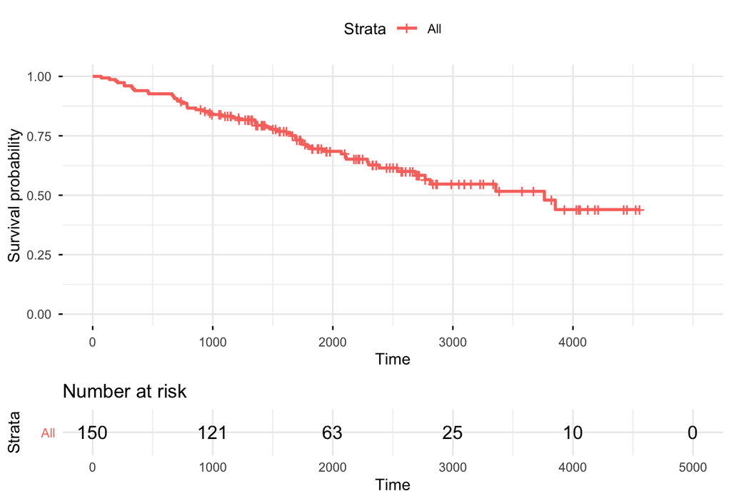

```r
ggsurvplot(
  km_sub,
  conf.int   = FALSE,
  risk.table = TRUE,
  ggtheme    = theme_minimal()
)
```

### 6.4.2 Survie “à la main” vs survfit() sur le même graphique

| time | d_i | c_i | cumulative_events | cumulative_censor | n_i |
| --- | --- | --- | --- | --- | --- |
| 71 | 1 | 0 | 1 | 0 | 150 |
| 140 | 1 | 0 | 2 | 0 | 149 |
| 191 | 1 | 0 | 3 | 0 | 148 |
| 207 | 1 | 0 | 4 | 0 | 147 |
| 264 | 2 | 0 | 6 | 0 | 146 |
| 326 | 1 | 0 | 7 | 0 | 144 |
| 334 | 1 | 0 | 8 | 0 | 143 |
| 348 | 1 | 0 | 9 | 0 | 142 |
| 460 | 1 | 0 | 10 | 0 | 141 |
| 466 | 1 | 0 | 11 | 0 | 140 |

[output cut: 43 more lines]

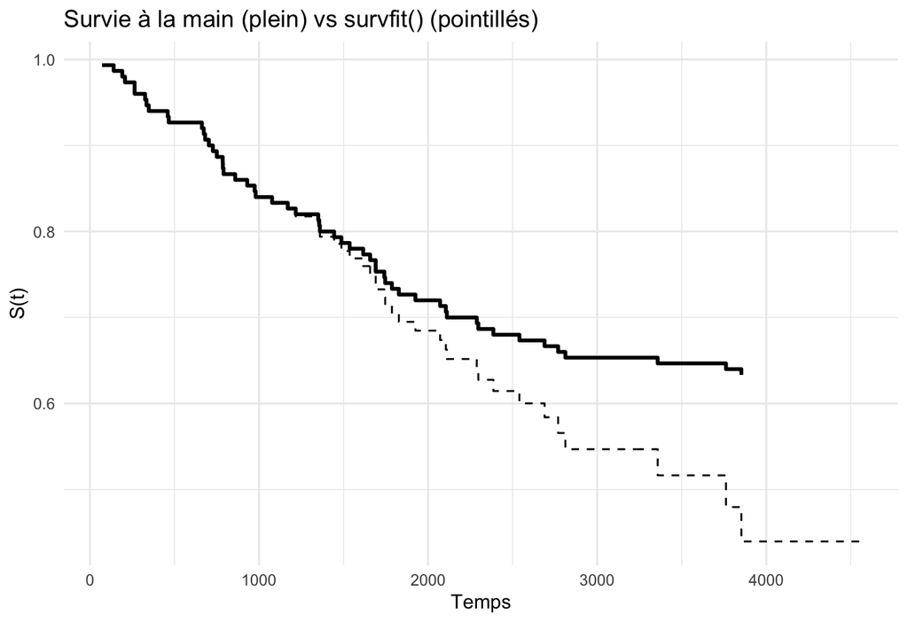

# 7 Ex3 – Hazard cumulé de Nelson–Aalen (calcul à la main)

> **Objectif :** comprendre le lien entre hazard discret, hazard cumulé et survie,  
> et utiliser la forme de $H(t)$ pour diagnostiquer l’évolution du hazard.

## 7.1 Rappel : hazard cumulé (définition)

Le **hazard cumulé** estimé par Nelson–Aalen est défini par :

$$\hat H(t_i) = \sum_{j : t_j \le t_i} \frac{d_j}{n_j}.$$

On peut l’interpréter comme une mesure cumulée du “risque instantané” accumulé dans le temps.

## 7.2 Calcul de $H_i$ et de la survie associée

```r
tab <- tab %>%
  dplyr::mutate(
    H_i  = cumsum(d_i / n_i),
    S_na = exp(-H_i)
  )

tab
```

| time | d_i | c_i | cumulative_events | cumulative_censor | n_i | h_i | S_i | H_i | S_na |
| --- | --- | --- | --- | --- | --- | --- | --- | --- | --- |
| 71 | 1 | 0 | 1 | 0 | 150 | 0.006666667 | 0.9933333 | 0.006666667 | 0.9933555 |
| 140 | 1 | 0 | 2 | 0 | 149 | 0.006711409 | 0.9866667 | 0.013378076 | 0.9867110 |
| 191 | 1 | 0 | 3 | 0 | 148 | 0.006756757 | 0.9800000 | 0.020134833 | 0.9800665 |
| 207 | 1 | 0 | 4 | 0 | 147 | 0.006802721 | 0.9733333 | 0.026937554 | 0.9734220 |
| 264 | 2 | 0 | 6 | 0 | 146 | 0.013698630 | 0.9600000 | 0.040636184 | 0.9601784 |
| 326 | 1 | 0 | 7 | 0 | 144 | 0.006944444 | 0.9533333 | 0.047580628 | 0.9535336 |
| 334 | 1 | 0 | 8 | 0 | 143 | 0.006993007 | 0.9466667 | 0.054573635 | 0.9468888 |
| 348 | 1 | 0 | 9 | 0 | 142 | 0.007042254 | 0.9400000 | 0.061615889 | 0.9402440 |
| 460 | 1 | 0 | 10 | 0 | 141 | 0.007092199 | 0.9333333 | 0.068708088 | 0.9335992 |
| 466 | 1 | 0 | 11 | 0 | 140 | 0.007142857 | 0.9266667 | 0.075850945 | 0.9269544 |

[output cut: 43 more lines]

**Questions :**

1. Pourquoi $H_i$ est-il toujours croissant ?
2. Que représente exactement la quantité $\exp(-H_i)$ ?

## 7.3 Visualiser le hazard cumulé

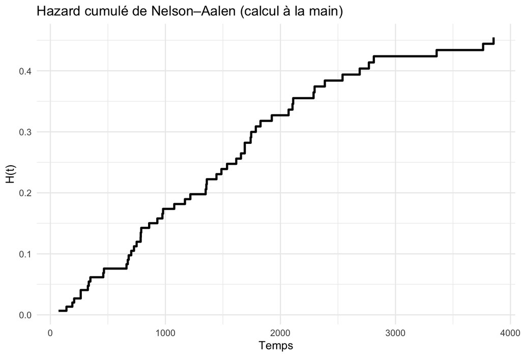

```r
ggplot(tab, aes(x = time, y = H_i)) +
  geom_step(linewidth = 1) +
  labs(
    title = "Hazard cumulé de Nelson–Aalen (calcul à la main)",
    x = "Temps",
    y = "H(t)"
  ) +
  theme_minimal()
```

**Questions d’interprétation :**

1. La courbe $H(t)$ est-elle plutôt linéaire, convexe ou concave ?
2. Que cela suggère-t-il sur la forme du hazard : constant, croissant, décroissant ?

## 7.4 Comparaison des survies : KM vs Nelson–Aalen

Nelson–Aalen fournit une approximation de la survie :

$$\tilde S(t) = \exp[-\hat H(t)].$$

On compare cette approximation à la survie $S_i$ obtenue via le produit-limite de Kaplan–Meier.

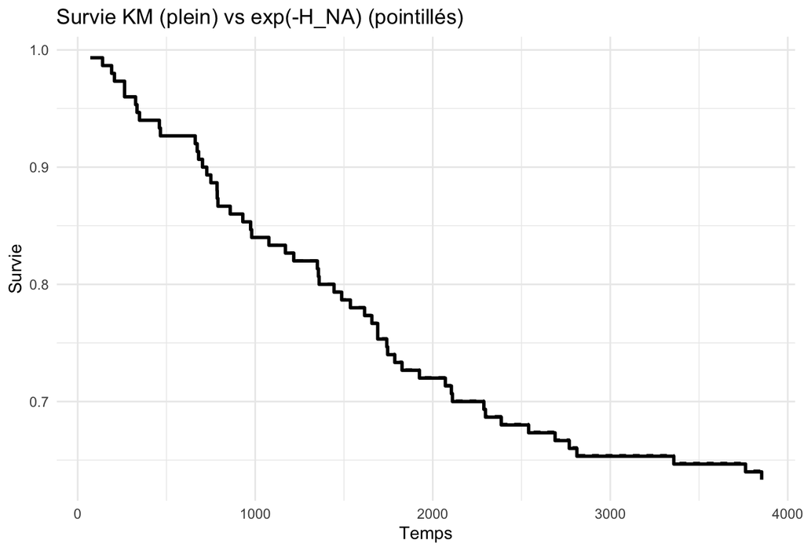

```r
ggplot(tab, aes(x = time)) +
  geom_step(aes(y = S_i),  linewidth = 1) +
  geom_step(aes(y = S_na), linetype = "dashed") +
  labs(
    title = "Survie KM (plein) vs exp(-H_NA) (pointillés)",
    x = "Temps",
    y = "Survie"
  ) +
  theme_minimal()
```

**Questions :**

1. Dans quels cas $S_{KM}(t)$ et $\exp[-H(t)]$ coïncident-ils presque parfaitement ?  
   (Indice : approximation $\log(1 - x) \approx -x$ pour $x$ petit.)
2. Pourquoi la version Nelson–Aalen tend-elle à légèrement surestimer la survie en fin de suivi ?

## 7.5 Résumé visuel : lire un hazard cumulé

**Lecture d’un hazard cumulé :**

- Courbe à peu près linéaire → hazard environ constant.
- Courbe convexe → hazard croissant dans le temps.
- Courbe concave → hazard décroissant.

# 8 Ex5 – Modèles paramétriques (exponentiel et Weibull)

> **Objectif de cours :** comprendre le lien entre la forme du hazard, la forme de la survie, et les hypothèses implicites des modèles exponentiel et Weibull.

## 8.1 Modèle exponentiel

```r
m_exp <- survreg(S ~ 1, data = df, dist = "exponential")
summary(m_exp)

# Dans survreg : scale = 1 / lambda
lambda_hat <- 1 / m_exp$scale
lambda_hat
```

```r
# Superposition KM vs modèle exponentiel
ggsurvplot(km, conf.int = FALSE) +
  stat_function(fun = function(t) exp(-lambda_hat * t))
```

**Questions – Modèle exponentiel**

1. La forme hazard constant vous semble-t-elle compatible avec la forme empirique de $H(t)$ ?
2. Comparez la médiane théorique $\log(2)/\hat\lambda$ à la médiane KM.

## 8.2 Modèle Weibull

```r
m_weib <- survreg(S ~ 1, data = df, dist = "weibull")
summary(m_weib)

k   <- 1 / m_weib$scale
lam <- exp(-m_weib$coefficients * k)

k
lam
```

```r
# Comparaison exponentiel vs Weibull
AIC(m_exp, m_weib)
BIC(m_exp, m_weib)
```

**Questions – Modèle Weibull**

1. Que signifie $k > 1$ / $k < 1$ en termes de hazard (croissant/décroissant) ?
2. Le Weibull améliore-t-il nettement l’ajustement (AIC/BIC, médiane) par rapport à l’exponentiel ?

**Liens avec les modèles paramétriques :**  
Si $H(t)$ est à peu près linéaire, un modèle exponentiel (hazard constant) est plausible.  
Si $H(t)$ est clairement convexe ou concave, un modèle Weibull (hazard croissant ou décroissant) est souvent plus adapté.

# 9 Ex6 – Modèles PH (Cox) et AFT (Weibull) avec covariables

> **Objectif de cours :** distinguer les deux grands cadres (PH vs AFT) et apprendre à lire HR vs TR.

**Rappel de cours – Modèle exponentiel**
Sans covariables, le modèle exponentiel suppose :
$$h(t) =
\lambda \quad (\text{hazard constant}), \qquad S(t) = \exp(-\lambda t).$$
La médiane de survie est :
$$\tilde t_{\text{exp}} = \frac{\log(2)}{\lambda}.$$
Un **hazard constant** implique que le risque instantané ne dépend pas de l’ancienneté (pas de “vieillissement” dans le temps).

## 9.1 Modèle de Cox (PH)

```r
cox1 <- coxph(S ~ age + sex + bili, data = df)
summary(cox1)

exp(coef(cox1))       # hazard ratios
exp(confint(cox1))    # intervalles de confiance sur HR
```

**Rappel : modèle PH de Cox**
$$h(t \mid X) = h_0(t)\,\exp(X\beta)$$
Un HR > 1 signifie un risque instantané plus élevé d’événement ; HR < 1, un risque plus faible.

## 9.2 Vérification de l’hypothèse PH

```r
zph <- cox.zph(cox1)
zph
ggcoxzph(zph)
```

**Lire les graphiques de `ggcoxzph()` :**

- Ligne horizontale ≈ effet constant dans le temps → compatible avec PH.
- Tendance clairement croissante ou décroissante → effet qui change dans le temps → violation possible de PH.
- On regarde la tendance globale, pas les petites oscillations locales.

**Questions – PH**

1. Certaines covariables semblent-elles violer PH (p-value faible) ?
2. Quelle forme prend leur courbe de résidus de Schoenfeld (croissante, décroissante) ?

## 9.3 Modèle Weibull AFT

**Rappel de cours – Modèle Weibull**
Sans covariables, le modèle Weibull suppose :
$$h(t) = \lambda k
t^{k-1}, \qquad S(t) = \exp(-\lambda t^k),$$
où :

- $k$ = paramètre de **forme**
- $\lambda$ = paramètre d’**échelle**

Interprétation :

- $k > 1$ : hazard **croissant** (risque qui augmente avec le temps)
- $k = 1$ : hazard **constant** (cas exponentiel)
- $k < 1$ : hazard **décroissant**

La médiane de survie est :
$$\tilde
t_{\text{Weibull}} = \left(\frac{\log(2)}{\lambda}\right)^{1/k}.$$

```r
m_weib <- survreg(S ~ 1, data = df, dist = "weibull")
summary(m_weib)

# Dans survreg (dist = "weibull") :
# scale = 1 / k
k_hat   <- 1 / m_weib$scale

# coef = log(lambda^{-1/k}) => lambda = exp(-coef * k)
lam_hat <- exp(-m_weib$coefficients * k_hat)

k_hat
lam_hat

# Médiane théorique Weibull
med_weib <- (log(2) / lam_hat)^(1 / k_hat)
med_weib


p_weib <- ggsurvplot(
  km,
  conf.int   = FALSE,
  risk.table = FALSE,
  ggtheme    = theme_minimal(),
  xlab       = "Temps (jours)",
  ylab       = "S(t)"
)

p_weib$plot +
  stat_function(
    fun = function(t) exp(-lam_hat * t^k_hat),
    linetype = "dashed"
  ) +
  labs(title = "Kaplan–Meier (plein) vs Weibull (pointillé)")
```

**Questions – Modèle Weibull**

1. Le paramètre de forme estimé $\hat k$ est-il supérieur, égal ou inférieur à 1 ? Reliez ce signe à la forme observée de $\hat H(t)$ (linéaire, convexe, concave).
2. Comparez visuellement :
   - KM vs exponentiel,
   - KM vs Weibull.

   Quel modèle semble le plus cohérent avec la médiane non paramétrique ?
4. Un modèle plus flexible comme Weibull “s’adapte” mieux à la forme de la survie. Pourquoi ne suffit-il pas de regarder la superposition graphique pour conclure qu’il est “meilleur” ? (Indice : pensez à la pénalisation de la complexité du modèle.)

**Rappel : modèle AFT**
$$\log(T) = X\gamma + \varepsilon
\quad \Leftrightarrow \quad
T = \exp(X\gamma)\, T_0.$$
TR > 1 : durée plus longue ; TR < 1 : durée plus courte.

```r
# Comparaison AIC
AIC(cox1)
AIC(aft_weib)
```

[output not shown]

[output not shown]

**Rappel – AIC / BIC**
$$\text{AIC} =
-2 \ell(\hat\theta) + 2k, \qquad \text{BIC} = -2 \ell(\hat\theta) + k
\log(n),$$
où $k$ est le nombre de paramètres, $n$ la taille de l’échantillon. Plus AIC/BIC sont **faibles**, meilleur est le compromis ajustement / complexité.

**Questions – Choix de modèle**

1. Lequel des deux modèles minimise l’AIC ? Le BIC ? La différence est-elle faible (< 2), modérée (≈ 2–5) ou forte (> 5) ?
2. Comment combiner :
   - les critères AIC/BIC,
   - la comparaison visuelle des courbes de survie,
   - et la plausibilité clinique/économique de la forme du hazard (croissant, décroissant, constant) ?

   pour justifier un choix de modèle auprès d’un non-spécialiste ?
3. Donnez un exemple de contexte (hors PBC) où un hazard **croissant** est naturel (ex. panne d’un moteur, faillite d’entreprise), et un contexte où un hazard **décroissant** serait plus plausible (ex. abandon d’un programme après une phase initiale).

**À retenir sur les modèles paramétriques**

- La forme de $\hat H(t)$ (linéaire / convexe / concave) est un outil clé pour choisir un modèle.
- L’exponentiel est un cas particulier du Weibull ($k = 1$).
- Un bon modèle paramétrique doit être *compatible* avec :
  - les diagnostics non paramétriques (KM, Nelson–Aalen),
  - les critères d’information (AIC/BIC),
  - et la logique économique/clinique du phénomène étudié.

# 10 Conclusion – Checklist de compétences

**Auto-checklist** – Cochez ce que vous savez faire seul·e :

- [ ] Créer un objet `Surv()` correctement codé.
- [ ] Tracer et commenter une courbe de Kaplan–Meier.
- [ ] Lire la forme du hazard (constant / croissant / décroissant) sur un hazard cumulé.
- [ ] Estimer et comparer un modèle exponentiel et Weibull (AIC, médiane théorique, forme du hazard).
- [ ] Estimer un modèle de Cox, interpréter les HR et vérifier l’hypothèse PH.
- [ ] Estimer un modèle AFT (Weibull), interpréter les time ratios et comparer à Cox.